# R Notebook

### Import Libraries

```r
install.packages("astsa")
```

## Askisi 4:

Στον επόμενο πίνακα δίνονται τα ποσά των ακάλυπτων επιταγών (σε εκατ. Ευρώ) ανά εποχή από το 2017 μέχρι το 2019 Να γίνει εξάλειψη της εποχικότητας των τιμών και να προσαρμοστεί η γραμμή τάσης. Στη συνέχεια να γίνει πρόβλεψη του ποσού των ακάλυπτων επιταγών για το φθινόπωρο του 2020

### Bima 1:

Fortonoume ta dedomena se ena R array.

```r
# declare data per year
data2017 = c(190.8, 132.1, 203.9, 211.3)
data2018 = c(302.3, 203.9, 236.2, 271.4)
data2019 = c(320.9, 250, 248.9, 280.3)

# combin data
data = append(data2017, data2018)
data = append(data, data2019)

data
```

```
 [1] 190.8 132.1 203.9 211.3 302.3 203.9 236.2 271.4 320.9 250.0 248.9 280.3
```

### Bima 2:

Pragmatopoioume elenxo ton dedomenon gia tin kaliteri katanoisi tous: - Elenxoume an ta data einai xronoseira. - Provaloume tin xronoseira - Ipologizoume ta ACF kai PACF

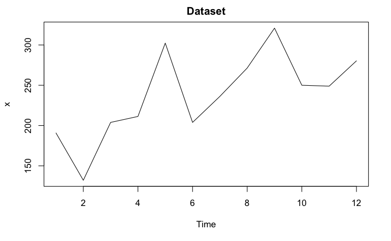

```r
x=ts(data)

# plot cmort data
plot.ts(x, main="Dataset")
```

```
     [,1] [,2]  [,3] [,4]  [,5]  [,6]
ACF  0.33 0.12 -0.04 0.20 -0.04 -0.24
PACF 0.33 0.01 -0.09 0.26 -0.21 -0.25
```

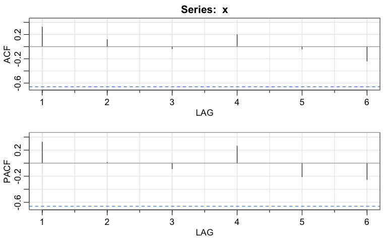

```r
# plot PACF
acf2(x)
```